# Cost of Alternative Housing Option and Strategic Default: Results

DC & DR

December 09, 2016

### Default %

```r
setwd(file_path)
# default_pct <- ddply(zillow_cox,.(ne_cutoff),summarise,default_rate = mean(def,na.rm = TRUE),obs=length(loanid))
# default_pct <- default_pct[order(-default_pct$ne_cutoff),]
# stargazer(default_pct,summary = FALSE,type = output.type)


# Positive Equity

pos_eqty <- readRDS("cox_ne_0.1_Dec082016.rds")
pos_eqty <- pos_eqty[,c("loanid","ne_cutoff","def")]
pos_eqty <- pos_eqty[!duplicated(pos_eqty[,c("loanid","ne_cutoff")]),]
temp  <- readRDS("cox_ne_0.2_Dec082016.rds")
temp <- temp[,c("loanid","ne_cutoff","def")]
temp <- temp[!duplicated(temp[,c("loanid","ne_cutoff")]),]
pos_eqty <- rbind(pos_eqty,temp)
temp  <- readRDS("cox_ne_0.5_Dec082016.rds")
temp <- temp[,c("loanid","ne_cutoff","def")]
temp <- temp[!duplicated(temp[,c("loanid","ne_cutoff")]),]
pos_eqty <- rbind(pos_eqty,temp)
temp <- zillow_cox[,c("loanid","ne_cutoff","def")]
pos_eqty <- rbind(pos_eqty,temp)

gc( verbose = FALSE)
```

```
##            used  (Mb) gc trigger   (Mb)  max used   (Mb)
## Ncells  9186217 490.6   14442815  771.4  10310024  550.7
## Vcells 48534748 370.3  150700180 1149.8 253479334 1933.9
```

```r
default_pct <- ddply(pos_eqty,.(ne_cutoff),summarise,default_rate = mean(def,na.rm = TRUE),obs=length(loanid))
default_pct <- default_pct[order(-default_pct$ne_cutoff),]
stargazer(default_pct,summary = FALSE,type = output.type)
```

```
##
## ==================================
##   ne_cutoff default_rate    obs
## ----------------------------------
## 7   0.500      0.020     1,115,516
## 6   0.200      0.028     1,189,686
## 5   0.100      0.028      641,332
## 4  -0.010      0.049      89,959
## 3  -0.100      0.061      61,978
## 2  -0.200      0.070      43,130
## 1  -0.500      0.077      11,816
## ----------------------------------
```

```r
rm(pos_eqty)
gc( verbose = FALSE)
```

```
##            used  (Mb) gc trigger  (Mb)  max used   (Mb)
## Ncells  2109475 112.7   11554252 617.1  10310024  550.7
## Vcells 22420272 171.1  120560144 919.9 253479334 1933.9
```

### low mpay_rent (<0.8) negative and positive equity default (Matched)

```
##
## =================================
##   Equity Negative Positive t-stat
## ---------------------------------
## 1 0.100   0.067    0.059   1.938
## 2 0.200   0.069    0.070   -0.182
## 3 0.500   0.121    0.014   50.856
## ---------------------------------
```

### high mpay_rent (>1.2) negative and positive equity default (Matched)

```
##
## =================================
##   Equity Negative Positive t-stat
## ---------------------------------
## 1 0.100   0.065    0.050   8.850
## 2 0.200   0.075    0.052   10.433
## 3 0.500   0.099    0.031   33.221
## ---------------------------------
```

### Illustration

Parameters: time 7 years;; loan age = 5 years; loan amount = 240,000; interest rate = 6%; default cost = 5000; foreclosure delay = 12 months; house price mu = 3%; house price sd 5%; Power utility with risk aversion = 2

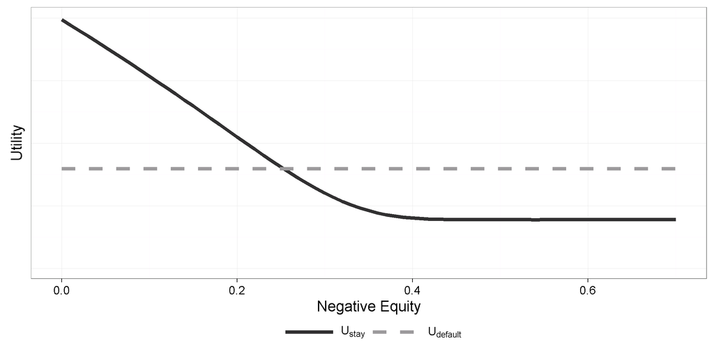

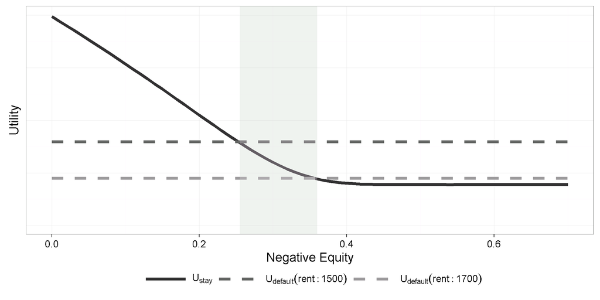

### Descriptive Statistics: Negative Equity Loans

```r
stargazer(
  zillow_cox[zillow_cox$ne_cutoff==-0.010, c("upb","fico","ltv","interest_diff","interestrate_avg","adjusted_mpay_rent","mpay","org_year","median_forc_time")], type = output.type,
  summary.stat = c("mean", "sd", "p25", "median", "p75", "n")
)
```

```
##
## =============================================================================
## Statistic             Mean      St. Dev.  Pctl(25)  Median   Pctl(75)    N
## -----------------------------------------------------------------------------
## upb                189,410.000 84,313.270 127,000   174,000   239,000  89,959
## fico                 730.842     52.962     694       738       774    89,847
## ltv                  79.979      10.058      75       80        89     89,959
## interest_diff         0.006      0.068     -0.036    0.001     0.041   89,959
## interestrate_avg      5.916      0.559     5.742     6.060     6.305   89,959
## adjusted_mpay_rent    1.102      0.262     0.950     1.095     1.258   89,959
## mpay                1,454.342   637.597   985.495  1,338.422 1,824.920 89,959
## org_year            2,006.906    1.711     2,006     2,007     2,008   89,959
## median_forc_time     13.077      2.151     11.000   13.000    15.000   89,958
## -----------------------------------------------------------------------------
```

### Descriptive Statistics: All loans (orginated between 2006 and 2008 and in same zipcodes)

```r
setwd(file_path)
allloans <- readRDS("freddie_orgination_data_upto_Q32015.rds")
allloans <- allloans[allloans$zip %in% unique(zillow_cox$zip),]
allloans['org_year'] <- as.integer(format(as.Date(as.character(allloans$orgdate)),"%Y"))
allloans <- allloans[allloans$org_year >= 2006 & allloans$org_year <= 2008,]

allloans['org_qt'] <- as.yearqtr(as.Date(as.character(allloans$orgdate)))
interestrate_zip <- readRDS("interestrate_zip.rds")
allloans <- merge(allloans,interestrate_zip,by=c("zip","org_qt"),all.x = TRUE)
allloans['interest_diff'] <- (allloans$interestrate - allloans$interestrate_avg)/allloans$interestrate_avg

stargazer(
  allloans[, c("upb","fico","ltv","interest_diff","interestrate_avg")], type = output.type,
  summary.stat = c("mean", "sd", "p25", "median", "p75", "n")
)
```

```
##
## ============================================================================
## Statistic           Mean      St. Dev.   Pctl(25) Median  Pctl(75)     N
## ----------------------------------------------------------------------------
## upb              205,918.300 100,494.200 128,000  188,000 270,000  1,429,423
## fico               727.873     56.883      687      735     776    1,428,287
## ltv                69.543      17.766       60      75       80    1,429,302
## interest_diff       0.000       0.067     -0.041  -0.003   0.036   1,429,423
## interestrate_avg    6.270       0.251     6.102    6.271   6.468   1,429,423
## ----------------------------------------------------------------------------
```

```r
rm(allloans)
gc( verbose = FALSE)
```

```
##            used  (Mb) gc trigger   (Mb)  max used   (Mb)
## Ncells  4491001 239.9   25859130 1381.1  40404892 2157.9
## Vcells 73970679 564.4  617469209 4711.0 964760911 7360.6
```

### Correlation

```r
cor_table <-cor(zillow_cox[zillow_cox$ne_cutoff==-0.01,c("adjusted_mpay_rent","fico","ltv","interest_diff","interestrate_avg","upb","org_hpi")],use = "complete.obs")

stargazer(cor_table,type=output.type,summary = FALSE)
```

```
##
## =================================================================================================
##                    adjusted_mpay_rent  fico   ltv   interest_diff interestrate_avg  upb   org_hpi
## -------------------------------------------------------------------------------------------------
## adjusted_mpay_rent         1          -0.098 0.090      0.098          0.189       -0.031 -0.053
## fico                     -0.098         1    0.045     -0.121          -0.250      0.056  -0.133
## ltv                      0.090        0.045    1        0.118          -0.295      0.002  -0.553
## interest_diff            0.098        -0.121 0.118        1            -0.100      -0.227 -0.097
## interestrate_avg         0.189        -0.250 -0.295    -0.100            1         -0.114  0.441
## upb                      -0.031       0.056  0.002     -0.227          -0.114        1     0.128
## org_hpi                  -0.053       -0.133 -0.553    -0.097          0.441       0.128     1
## -------------------------------------------------------------------------------------------------
```

### mpay/rent histogram

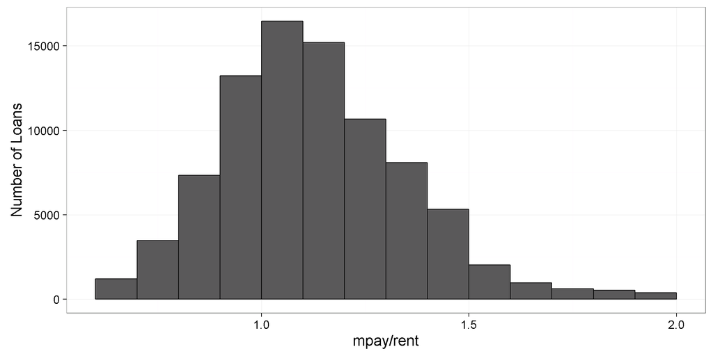

```r
ggplot(data=zillow_cox[zillow_cox$ne_cutoff==-0.01,], aes(zillow_cox[zillow_cox$ne_cutoff==-0.01,]$adjusted_mpay_rent)) +
  geom_histogram(breaks=seq(0.6,2, by=0.1),col="black")+ylab("Number of Loans")+xlab("mpay/rent") + theme_bw(base_size = 18)
```

### mpay/rent maps

[figure not shown]

[figure not shown]

### Rent Regression using house level data

```r
setwd(file_path)
rentdata <- readRDS("zillow_houselevel_rentdata.rds")

ols <- list()
se <- list()
ols[[1]] <- lm(log(rent)~log(zest_value)+factor(state),data = rentdata)
  se[[1]] <-sqrt(diag(cluster.vcov(ols[[1]], cbind(rentdata$state))))
ols[[2]] <- lm(log(rent)~log(zest_value)+beds+baths+sqft+avg_school_rating+prop_tax_pct+forc_pct+hpi_change+factor(state),data = rentdata)
  se[[2]] <-sqrt(diag(cluster.vcov(ols[[2]], cbind(rentdata$state))))
ols[[3]] <- lm(log(rent)~beds+baths+sqft+log(zest_value)+avg_school_rating+prop_tax_pct+forc_pct+hpi_change+Lot+I(2016-Builtin)+future_price_appr+factor(state),data = rentdata)
  se[[3]] <-sqrt(diag(cluster.vcov(ols[[3]], cbind(rentdata$state))))
ols[[4]] <- lm(mpay_rent~beds+baths+sqft+log(zest_value)+avg_school_rating+prop_tax_pct+forc_pct+hpi_change+Lot+I(2016-Builtin)+future_price_appr+factor(state),data = rentdata)
  se[[4]] <-sqrt(diag(cluster.vcov(ols[[4]], cbind(rentdata$state))))

stargazer(ols,type = output.type,no.space = TRUE,omit=c("state"),omit.labels = c("state"),se=se,notes = "Standard Errors clustered by state",title = "House Level",omit.stat = c("f","ser"))
```

```
##
## House Level
## =========================================================
##                             Dependent variable:
##                   ---------------------------------------
##                             log(rent)           mpay_rent
##                     (1)       (2)        (3)       (4)
## ---------------------------------------------------------
## log(zest_value)   0.627***  0.589***  0.506***  0.324***
##                   (0.024)   (0.039)    (0.056)   (0.038)
## beds                        0.042**    0.049**  -0.039***
##                             (0.017)    (0.022)   (0.013)
## baths                       0.078***  0.110***  -0.082***
##                             (0.012)    (0.026)   (0.027)
## sqft                       0.00000*** -0.00000   0.00001
##                            (0.00000)  (0.00002) (0.00002)
## avg_school_rating            -0.005    -0.003    0.00000
##                             (0.006)    (0.005)   (0.004)
## prop_tax_pct                18.687*     1.509     0.180
##                             (11.236)   (4.159)   (2.100)
## forc_pct                     -0.005    -0.002     0.004
##                             (0.004)    (0.002)   (0.003)
## hpi_change                   0.444*     0.389   -0.435***
##                             (0.243)    (0.307)   (0.135)
## Lot                                    0.00000  -0.00000
##                                       (0.00000) (0.00000)
## I(2016 - Builtin)                       0.001    -0.0001
##                                        (0.001)  (0.0005)
## future_price_appr                     -3.191***  1.358*
##                                        (0.551)   (0.748)
## Constant           -0.287   -0.679*     0.423   -2.767***
##                   (0.299)   (0.378)    (0.473)   (0.403)
## ---------------------------------------------------------
## state               Yes       Yes        Yes       Yes
## ---------------------------------------------------------
## Observations       23,618    9,706      2,179     2,179
## R2                 0.815     0.876      0.913     0.482
## Adjusted R2        0.815     0.875      0.912     0.473
## =========================================================
## Note:                         *p<0.1; **p<0.05; ***p<0.01
##                        Standard Errors clustered by state
```

### Rent Prediction

```r
ols <- lm(log(rent)~log(zest_value)+I(log(zest_value)^2)+I(log(zest_value)^3)+I(log(zest_value)^4)+I(log(zest_value)^5)+factor(state),data = rentdata)


zillow_cox['zest_value'] <- zillow_cox$current_housevalue
zillow_cox['rent_hat'] <- predict(ols,zillow_cox)
zillow_cox['mpay_rent_hat']<-zillow_cox$mpay/(zillow_cox$rent_hat)

summary(ols)$r.sq
```

```
## [1] 0.8265082
```

### Main model : Cox PH

```r
cox_formula<-list()

cox_formula[[1]] <- as.formula("Surv(duration,def)~adjusted_mpay_rent+median_forc_time+interestrate+age_t+age_t*age_t+factor(ne_year)+fico+ltv+dti+avg_school_rating+medhhincome+medhouseage+vacantpct+bachelorpct+withsalarypct+factor(occupancy)+factor(purpose)+factor(state)+factor(ne_cutoff)+log(upb)/ltv+mpay/dti+default_pct+hpi_change+forc_pct")



cox <-list()
cox[[1]] <- coxph(cox_formula[[1]],data = zillow_cox,control = coxph.control(iter.max = 1000))
cox[[2]] <- coxph(cox_formula[[1]],data = zillow_cox[zillow_cox$adjusted_mpay_rent<1,],control = coxph.control(iter.max = 1000))
cox[[3]] <- coxph(cox_formula[[1]],data = zillow_cox[zillow_cox$adjusted_mpay_rent>=1,],control = coxph.control(iter.max = 1000))

stargazer(cox,type = output.type,no.space = TRUE,omit = c("state","ne_year","ne_cutoff","occupancy","purpose"),omit.labels =  c("state","ne year","ne cutoff","occupancy","purpose"),column.labels = c("All","mpayrent < 1","mpayrent > 1"),omit.stat = c("ll","logrank","max.rsq","lr","wald"))
```

```
##
## ========================================================
##                             Dependent variable:
##                    -------------------------------------
##                                 cox_formula
##                        All     mpayrent < 1 mpayrent > 1
##                        (1)         (2)          (3)
## --------------------------------------------------------
## adjusted_mpay_rent  0.187***    -1.469***     1.299***
##                      (0.044)     (0.184)      (0.056)
## median_forc_time    0.062***    -0.114***      0.037*
##                      (0.013)     (0.021)      (0.021)
## interestrate        0.466***     0.687***     0.444***
##                      (0.021)     (0.040)      (0.025)
## age_t               0.005***     0.016***      0.001
##                      (0.001)     (0.001)      (0.001)
## fico                -0.006***   -0.006***    -0.006***
##                     (0.0002)     (0.0003)     (0.0002)
## ltv                   0.044      -0.089*      0.124***
##                      (0.027)     (0.050)      (0.033)
## dti                 0.007***     0.008**      0.005**
##                      (0.002)     (0.004)      (0.003)
## avg_school_rating   0.095***    -0.217***     0.141***
##                      (0.012)     (0.027)      (0.014)
## medhhincome        0.00002***   0.00004***   0.00002***
##                     (0.00000)   (0.00001)    (0.00000)
## medhouseage         0.021***     0.041***     0.011***
##                      (0.002)     (0.005)      (0.002)
## vacantpct           1.240***      -0.956      2.164***
##                      (0.383)     (0.928)      (0.469)
## bachelorpct         3.378***    -13.082***    4.190***
##                      (0.454)     (1.345)      (0.528)
## withsalarypct       -3.160***   29.466***    -6.166***
##                      (0.875)     (2.353)      (1.011)
## log(upb)            0.614***      -0.403      1.807***
##                      (0.211)     (0.380)      (0.261)
## mpay                -0.0002**    -0.0001     -0.001***
##                     (0.0001)     (0.0001)     (0.0001)
## default_pct         35.805***   -90.555***   44.504***
##                      (4.954)     (10.540)     (6.156)
## hpi_change          -1.229***   -2.084***    -3.172***
##                      (0.298)     (0.723)      (0.372)
## forc_pct           -188.748***  718.167***  -257.689***
##                     (52.437)    (129.175)     (61.704)
## ltv:log(upb)         -0.003       0.006      -0.009***
##                      (0.002)     (0.004)      (0.003)
## dti:mpay             0.00000     0.00000     0.00000**
##                     (0.00000)   (0.00000)    (0.00000)
## --------------------------------------------------------
## state                  Yes         Yes          Yes
## ne year                Yes         Yes          Yes
## ne cutoff              Yes         Yes          Yes
## occupancy              Yes         Yes          Yes
## purpose                Yes         Yes          Yes
## --------------------------------------------------------
## Observations         199,754      54,244      145,510
## R2                    0.042       0.085        0.042
## ========================================================
## Note:                        *p<0.1; **p<0.05; ***p<0.01
```

```r
cox <- NULL
gc( verbose = FALSE)
```

```
##            used  (Mb) gc trigger   (Mb)  max used   (Mb)
## Ncells  4600738 245.8   20687304 1104.9  40404892 2157.9
## Vcells 86912144 663.1  493975367 3768.8 964760911 7360.6
```

### Main model : Logit

```r
logit_formula<-list()

logit_formula[[1]] <- as.formula("def~adjusted_mpay_rent+median_forc_time+interestrate+age_t+age_t*age_t+factor(ne_year)+fico+ltv+dti+avg_school_rating+medhhincome+medhouseage+vacantpct+bachelorpct+withsalarypct+factor(occupancy)+factor(purpose)+factor(state)+factor(ne_cutoff)+log(upb)/ltv+mpay/dti+default_pct+hpi_change+forc_pct")



logit <-list()
logit[[1]] <- glm(logit_formula[[1]],data = zillow_cox,family=binomial(link='logit'))
logit[[2]] <- glm(logit_formula[[1]],family=binomial(link='logit'),data = zillow_cox[zillow_cox$adjusted_mpay_rent<1,])
logit[[3]] <- glm(logit_formula[[1]],family=binomial(link='logit'),data = zillow_cox[zillow_cox$adjusted_mpay_rent>=1,])

stargazer(logit,type = output.type,no.space = TRUE,omit = c("state","ne_year","ne_cutoff","occupancy","purpose"),omit.labels =  c("state","ne year","ne cutoff","occupancy","purpose"),column.labels = c("All","mpayrent < 1","mpayrent > 1"),omit.stat = c("ll","logrank","max.rsq","lr","wald"))
```

```
##
## ========================================================
##                             Dependent variable:
##                    -------------------------------------
##                                logit_formula
##                        All     mpayrent < 1 mpayrent > 1
##                        (1)         (2)          (3)
## --------------------------------------------------------
## adjusted_mpay_rent  0.204***    -2.368***     1.587***
##                      (0.047)     (0.234)      (0.069)
## median_forc_time    0.071***    -0.125***      0.042*
##                      (0.014)     (0.023)      (0.023)
## interestrate        0.482***     0.846***     0.442***
##                      (0.023)     (0.047)      (0.027)
## age_t               0.005***     0.020***      0.001
##                      (0.001)     (0.001)      (0.001)
## fico                -0.007***   -0.007***    -0.007***
##                     (0.0002)     (0.0004)     (0.0002)
## ltv                  0.058**      -0.085      0.143***
##                      (0.029)     (0.058)      (0.035)
## dti                 0.007***     0.011***      0.004
##                      (0.002)     (0.004)      (0.003)
## avg_school_rating   0.111***    -0.258***     0.162***
##                      (0.013)     (0.031)      (0.015)
## medhhincome        0.00002***   0.0001***    0.00002***
##                     (0.00000)   (0.00001)    (0.00000)
## medhouseage         0.026***     0.066***     0.014***
##                      (0.002)     (0.006)      (0.003)
## vacantpct           1.600***      -0.892      2.745***
##                      (0.412)     (1.081)      (0.510)
## bachelorpct         3.795***    -15.887***    4.601***
##                      (0.482)     (1.563)      (0.558)
## withsalarypct       -3.912***   30.273***    -6.905***
##                      (0.926)     (2.646)      (1.074)
## log(upb)            0.669***      -0.507      1.936***
##                      (0.224)     (0.443)      (0.277)
## mpay                -0.0002**    -0.0001     -0.001***
##                     (0.0001)     (0.0002)     (0.0001)
## default_pct         41.152***  -100.442***   52.533***
##                      (5.279)     (12.076)     (6.576)
## hpi_change          -1.418***   -3.825***    -3.690***
##                      (0.320)     (0.856)      (0.403)
## forc_pct           -218.144***  816.431***  -306.735***
##                     (55.743)    (154.284)     (65.947)
## ltv:log(upb)         -0.004       0.006      -0.010***
##                      (0.002)     (0.005)      (0.003)
## dti:mpay            0.00000*     0.00000     0.00000***
##                     (0.00000)   (0.00000)    (0.00000)
## Constant           -11.973***     -1.842     -28.127***
##                      (2.774)     (5.521)      (3.473)
## --------------------------------------------------------
## state                  Yes         Yes          Yes
## ne year                Yes         Yes          Yes
## ne cutoff              Yes         Yes          Yes
## occupancy              Yes         Yes          Yes
## purpose                Yes         Yes          Yes
## --------------------------------------------------------
## Observations         199,754      54,244      145,510
## Akaike Inf. Crit.  79,698.100   19,657.760   57,389.030
## ========================================================
## Note:                        *p<0.1; **p<0.05; ***p<0.01
```

```r
logit <- NULL
gc( verbose = FALSE)
```

```
##            used  (Mb) gc trigger   (Mb)  max used   (Mb)
## Ncells  4601742 245.8   16549843  883.9  40404892 2157.9
## Vcells 86914390 663.2  395180293 3015.0 964760911 7360.6
```

### Alternative Measures: Cox PH

```r
cox_formula[[2]] <- as.formula("Surv(duration,def)~rent_pct+median_forc_time+interestrate+age_t+age_t*age_t+factor(ne_year)+fico+ltv+dti+avg_school_rating+medhhincome+medhouseage+vacantpct+bachelorpct+withsalarypct+factor(occupancy)+factor(purpose)+factor(state)+factor(ne_cutoff)+log(upb)/ltv+mpay/dti+default_pct+hpi_change+forc_pct")

cox_formula[[3]] <- as.formula("Surv(duration,def)~log(rent_diff)+median_forc_time+interestrate+age_t+age_t*age_t+factor(ne_year)+fico+ltv+dti+avg_school_rating+medhhincome+medhouseage+vacantpct+bachelorpct+withsalarypct+factor(occupancy)+factor(purpose)+factor(state)+factor(ne_cutoff)+log(upb)/ltv+mpay/dti+default_pct+hpi_change+forc_pct")

cox_formula[[4]] <- as.formula("Surv(duration,def)~agents+median_forc_time+interestrate+age_t+age_t*age_t+factor(ne_year)+fico+ltv+dti+avg_school_rating+medhhincome+medhouseage+vacantpct+bachelorpct+withsalarypct+factor(occupancy)+factor(purpose)+factor(state)+factor(ne_cutoff)+log(upb)/ltv+mpay/dti+default_pct+hpi_change+forc_pct")

cox_formula[[5]] <- as.formula("Surv(duration,def)~mpay_rent_hat+median_forc_time+interestrate+age_t+age_t*age_t+factor(ne_year)+fico+ltv+dti+avg_school_rating+medhhincome+medhouseage+vacantpct+bachelorpct+withsalarypct+factor(occupancy)+factor(purpose)+factor(state)+factor(ne_cutoff)+log(upb)/ltv+mpay/dti+default_pct+hpi_change+forc_pct")

cox <-list()
cox[[1]] <- coxph(cox_formula[[2]],data = zillow_cox,control = coxph.control(iter.max = 1000))
#cox[[5]] <- coxph(cox_formula[[3]],data = zillow_cox,control = coxph.control(iter.max = 1000))
cox[[2]] <- coxph(cox_formula[[4]],data = zillow_cox,control = coxph.control(iter.max = 1000))
cox[[3]] <- coxph(cox_formula[[5]],data = zillow_cox,control = coxph.control(iter.max = 1000))
stargazer(cox,type = output.type,no.space = TRUE,omit = c("state","ne_year","ne_cutoff","occupancy","purpose"),omit.labels =  c("state","ne year","ne cutoff","occupancy","purpose"),omit.stat = c("ll","logrank","max.rsq","lr","wald"))
```

```
##
## ====================================================
##                          Dependent variable:
##                   ----------------------------------
##                              cox_formula
##                       (1)        (2)         (3)
## ----------------------------------------------------
## rent_pct           1.543***
##                     (0.271)
## agents                         0.001***
##                                (0.0001)
## mpay_rent_hat                             0.034***
##                                            (0.004)
## median_forc_time   0.053***    0.066***   0.062***
##                     (0.013)    (0.013)     (0.013)
## interestrate       0.480***    0.485***   0.405***
##                     (0.021)    (0.021)     (0.022)
## age_t              0.005***    0.005***   0.004***
##                     (0.001)    (0.001)     (0.001)
## fico               -0.006***  -0.006***   -0.006***
##                    (0.0002)    (0.0002)   (0.0002)
## ltv                 0.047*      0.043       0.039
##                     (0.027)    (0.027)     (0.027)
## dti                0.007***    0.007***   0.006***
##                     (0.002)    (0.002)     (0.002)
## avg_school_rating  0.091***    0.038***   0.083***
##                     (0.011)    (0.012)     (0.011)
## medhhincome       0.00003***  0.00001*** 0.00002***
##                    (0.00000)  (0.00000)   (0.00000)
## medhouseage         0.006*     0.020***   0.022***
##                     (0.003)    (0.002)     (0.002)
## vacantpct            0.450      -0.134     0.751**
##                     (0.372)    (0.386)     (0.369)
## bachelorpct        2.386***     0.262     2.899***
##                     (0.465)    (0.540)     (0.449)
## withsalarypct      -6.010***  -3.018***   -3.253***
##                     (1.006)    (0.885)     (0.876)
## log(upb)           0.585***    0.579***     0.164
##                     (0.210)    (0.210)     (0.215)
## mpay               -0.0001*    -0.0001*   -0.004***
##                    (0.0001)    (0.0001)   (0.0004)
## default_pct        32.096***   10.487**   29.017***
##                     (4.725)    (5.120)     (4.736)
## hpi_change         -1.104***  -1.299***   -1.249***
##                     (0.299)    (0.297)     (0.297)
## forc_pct          -155.547***   13.928   -148.336***
##                    (50.736)    (53.234)   (51.003)
## ltv:log(upb)        -0.003      -0.003     -0.002
##                     (0.002)    (0.002)     (0.002)
## dti:mpay            0.00000    0.00000    0.00000*
##                    (0.00000)  (0.00000)   (0.00000)
## ----------------------------------------------------
## state                 Yes        Yes         Yes
## ne year               Yes        Yes         Yes
## ne cutoff             Yes        Yes         Yes
## occupancy             Yes        Yes         Yes
## purpose               Yes        Yes         Yes
## ----------------------------------------------------
## Observations        199,754    199,754     199,754
## R2                   0.042      0.042       0.042
## ====================================================
## Note:                    *p<0.1; **p<0.05; ***p<0.01
```

```r
cox <- NULL
gc( verbose = FALSE)
```

```
##            used  (Mb) gc trigger   (Mb)  max used   (Mb)
## Ncells  4602191 245.8   13239874  707.1  40404892 2157.9
## Vcells 86915421 663.2  316144234 2412.0 964760911 7360.6
```

### LPM Model with standard errors clustered by zip code and time

```r
library(multiwayvcov)
library(sandwich)


lpm_formula <- list()
lpm_formula[[1]] <- as.formula("def~adjusted_mpay_rent+median_forc_time+interestrate+age_t+fico+ltv+dti+medhhincome+medhouseage+vacantpct+bachelorpct+withsalarypct+factor(occupancy)+factor(purpose)+factor(ne_cutoff)+default_pct+hpi_change+forc_pct+factor(zip)+factor(ne_year)+upb")

lpm <- list()
se <- list()
lpm[[1]] <- lm(lpm_formula[[1]],data=zillow_cox)
se[[1]] <-sqrt(diag(cluster.vcov(lpm[[1]], cbind(zillow_cox$zip,zillow_cox$ne_year))))

stargazer(lpm,type=output.type,no.space=TRUE,omit=c("zip","ne_year","purpose","occupancy","ne_cutoff"))
```

```
##
## ================================================
##                         Dependent variable:
##                     ----------------------------
##                             lpm_formula
## ------------------------------------------------
## adjusted_mpay_rent            0.043***
##                               (0.003)
## median_forc_time              0.903***
##                               (0.127)
## interestrate                  0.021***
##                               (0.001)
## age_t                         0.00003
##                              (0.00003)
## fico                         -0.0004***
##                              (0.00001)
## ltv                           0.001***
##                               (0.0001)
## dti                          0.0005***
##                              (0.00004)
## medhhincome                  0.00001***
##                              (0.00000)
## medhouseage                   -0.001**
##                               (0.001)
## vacantpct                     1.050***
##                               (0.056)
## bachelorpct                    0.048
##                               (0.102)
## withsalarypct                 0.959***
##                               (0.180)
## default_pct                  70.838***
##                               (12.663)
## hpi_change                   -60.021***
##                               (8.726)
## forc_pct                   11,350.660***
##                             (1,555.712)
## upb                          0.00000***
##                               (0.000)
## Constant                     -26.003***
##                               (3.589)
## ------------------------------------------------
## Observations                  199,767
## R2                             0.057
## Adjusted R2                    0.056
## Residual Std. Error     0.227 (df = 199598)
## F Statistic         71.503*** (df = 168; 199598)
## ================================================
## Note:                *p<0.1; **p<0.05; ***p<0.01
```

### LPM Prediction for 10% negative equity sample

Using only statistically significant variables

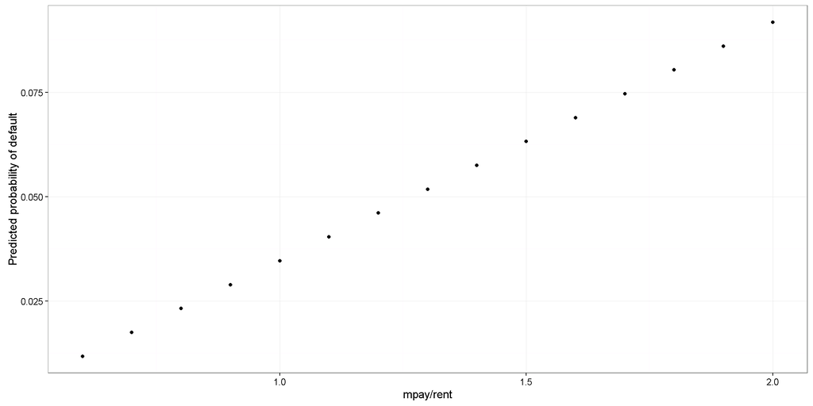

```r
lpm_sum <- summary(lm(def~adjusted_mpay_rent+median_forc_time+interestrate+age_t+fico+ltv+dti+factor(zip)+factor(ne_year)+upb,data = zillow_cox[zillow_cox$ne_cutoff== - 0.1,]))
lpm_coef <- as.data.frame(lpm_sum$coefficients)
lpm_coef['x']<- row.names(lpm_coef)
lpm_coef$`Std. Error` <-NULL
lpm_coef$`Pr(>|t|)` <- NULL
lpm_coef$`t value` <- NULL

factor_zip <- mean(lpm_coef[substr(lpm_coef$x,1,11)=="factor(zip)",]$Estimate)
lpm_coef <- lpm_coef[substr(lpm_coef$x,1,11)!="factor(zip)",]
factor_ne_year<- mean(lpm_coef[substr(lpm_coef$x,1,15)=="factor(ne_year)",]$Estimate)
lpm_coef <- lpm_coef[substr(lpm_coef$x,1,15)!="factor(ne_year)",]

lpm_coef <- lpm_coef[!lpm_coef$x %in% c("factor(ne_cutoff)-0.01","factor(ne_cutoff)-0.2","factor(occupancy)S","factor(purpose)N","factor(purpose)P"),]

lpm_coef['value'] <- NA
lpm_coef[lpm_coef$x=="(Intercept)",'value']=0
lpm_coef[lpm_coef$x=="median_forc_time",'value'] = 0 #mean(zillow_cox[zillow_cox$ne_cutoff== -0.1,]$median_forc_time,na.rm = TRUE)
lpm_coef[lpm_coef$x=="interestrate",'value'] = mean(zillow_cox[zillow_cox$ne_cutoff== -0.1,]$interestrate,na.rm = TRUE)
lpm_coef[lpm_coef$x=="age_t",'value'] = 0 #mean(zillow_cox[zillow_cox$ne_cutoff== -0.1,]$age_t,na.rm = TRUE)
lpm_coef[lpm_coef$x=="fico",'value'] = mean(zillow_cox[zillow_cox$ne_cutoff== -0.1,]$fico,na.rm = TRUE)
lpm_coef[lpm_coef$x=="ltv",'value'] = mean(zillow_cox[zillow_cox$ne_cutoff== -0.1,]$ltv,na.rm = TRUE)
lpm_coef[lpm_coef$x=="dti",'value'] = mean(zillow_cox[zillow_cox$ne_cutoff== -0.1,]$dti,na.rm = TRUE)
lpm_coef[lpm_coef$x=="upb",'value'] = mean(zillow_cox[zillow_cox$ne_cutoff== -0.1,]$upb,na.rm = TRUE)

lpm_coef[lpm_coef$x=="adjusted_mpay_rent",'value'] = 0.5


x = seq(0.6,2,0.1)
y = rep(NA, length(x))

for(i in 1:length(x))  {
  lpm_coef[lpm_coef$x=="adjusted_mpay_rent",'value'] = x[i]
  lpm_coef['pred'] <- lpm_coef$Estimate*lpm_coef$value
  y[i]= sum(lpm_coef$pred)+factor_zip+factor_ne_year
}

plot_data <- as.data.frame(cbind(x,y))

ggplot(plot_data,aes(x=x,y=y))+geom_point()+
  theme(axis.text.y=element_blank(),
        axis.ticks.y=element_blank())+labs(x = "mpay/rent",y="Predicted probability of default")+ theme_bw()
```

### Hazard Contribution

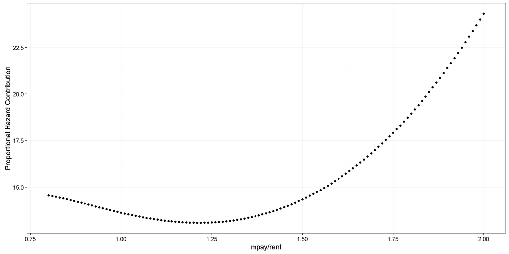

```r
cox_formula <- as.formula("Surv(duration,def)~adjusted_mpay_rent+I(adjusted_mpay_rent^2)+I(adjusted_mpay_rent^3)+I(adjusted_mpay_rent^4)+I(adjusted_mpay_rent^5)+median_forc_time+interest_diff+age_t+age_t*age_t+factor(ne_year)+fico+ltv+dti+medhhincome+medhouseage+vacantpct+bachelorpct+withsalarypct+factor(occupancy)+factor(purpose)+factor(state)+factor(ne_cutoff)+log(upb)/ltv+mpay/dti+default_pct+hpi_change+forc_pct")

cox <- coxph(cox_formula,data = zillow_cox,control = coxph.control(iter.max = 100))

x = (80:200)/100
y = exp((summary(cox)$coefficients)[1,1] * x +(summary(cox)$coefficients)[2,1] * x^2 +(summary(cox)$coefficients)[3,1] * x^3 +(summary(cox)$coefficients)[4,1] * x^4 +(summary(cox)$coefficients)[5,1] * x^5)
plot_data <- as.data.frame(cbind(x,y))

ggplot(plot_data,aes(x=x,y=y))+geom_point()+
  theme(axis.text.y=element_blank(),
        axis.ticks.y=element_blank())+labs(x = "mpay/rent",y="Proportional Hazard Contribution")+ theme_bw()
```

```r
cox <- NULL
gc( verbose = FALSE)
```

```
##             used  (Mb) gc trigger   (Mb)  max used   (Mb)
## Ncells   4770580 254.8   13239874  707.1  40404892 2157.9
## Vcells 120097703 916.3  316144234 2412.0 964760911 7360.6
```

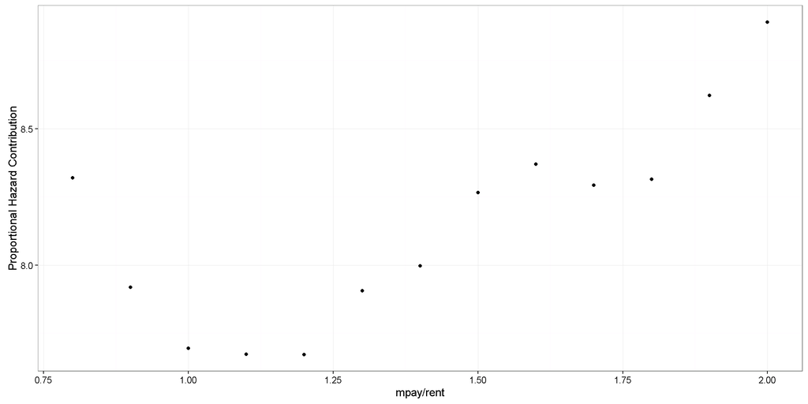

```r
cox_formula <- as.formula("Surv(duration,def)~factor((adjusted_mpay_rent %/% 0.1)/10)+median_forc_time+interest_diff+age_t+age_t*age_t+factor(ne_year)+fico+ltv+dti+medhhincome+medhouseage+vacantpct+bachelorpct+withsalarypct+factor(occupancy)+factor(purpose)+factor(state)+factor(ne_cutoff)+log(upb)/ltv+mpay/dti+default_pct+hpi_change+forc_pct")

cox <- coxph(cox_formula,data = zillow_cox,control = coxph.control(iter.max = 100))

x = seq(0.8,2,0.1)
y = as.vector((summary(cox)$coefficients)[7:19,1])
plot_data <- as.data.frame(cbind(x,y))

ggplot(plot_data,aes(x=x,y=y))+geom_point()+
  theme(axis.text.y=element_blank(),
        axis.ticks.y=element_blank())+labs(x = "mpay/rent",y="Proportional Hazard Contribution")+ theme_bw()
```

```r
cox <- NULL
gc( verbose = FALSE)
```

```
##             used  (Mb) gc trigger   (Mb)  max used   (Mb)
## Ncells   4781383 255.4   13239874  707.1  40404892 2157.9
## Vcells 120121065 916.5  316144234 2412.0 964760911 7360.6
```

### Two Stage Least Squres

Using the **10% negative equity subsample**. Similar results for other negative equity subsamples and for the combined sample.

**Diagnostic tests:**  
Weak instruments : statistic 2664.73; p-value < 2e-16  
*Wu-Hausman : statistic 43.26; p-value 4.84e-11*

```r
temp <- zillow_cox[zillow_cox$ne_cutoff==-0.1,]
temp <- temp[!duplicated(temp[,c("loanid","ne_cutoff")]),]
temp['org_qt']<-as.yearqtr(as.Date(as.character(temp$orgdate)))
temp = temp[temp$loanterm==360,]
temp['current_hv_cat'] <- temp$current_housevalue %/% 25000
temp['zip_year'] <- paste(temp$zip,temp$ne_year,sep="_")

#temp2 <- ddply(temp,.(zip_year),summarise,obs = length(loanid))

#temp <- temp[temp$zip_year %in% temp2[temp2$obs<25,]$zip_year,]

iv_reg <- list()
iv_reg[[1]] <- lm(def ~ adjusted_mpay_rent + fico + ltv+ dti + log(upb) + current_hv_cat+interest_diff *factor(zip_year), data=temp)
iv_reg[[2]] <- ivreg(def ~ adjusted_mpay_rent +current_hv_cat+factor(zip_year) | interestrate_avg+age_t +current_hv_cat+factor(zip_year), data=temp)
iv_reg[[3]] <- ivreg(def ~ adjusted_mpay_rent + fico + ltv+ dti + log(upb) + current_hv_cat+interest_diff +factor(zip_year) | fico + ltv+ dti + log(upb) +current_hv_cat+ interestrate_avg+ interest_diff + age_t +factor(occupancy) + factor(purpose)+factor(zip_year), data=temp)
iv_reg[[4]] <- lm(adjusted_mpay_rent~interestrate_avg+age_t+fico + current_hv_cat+ltv+ dti + log(upb) + interest_diff + factor(zip_year) , data=temp)

stargazer(iv_reg,type = output.type,no.space = TRUE,omit = c("zip_year","purpose","occupancy"),omit.labels = c("zip * year","purpose","occupancy"),column.labels   = c("OLS","Two Stage", "First Stage"),   column.separate = c(1,2, 1),omit.stat = c("f","ser","rsq"))
```

```
##
## ====================================================================
##                                   Dependent variable:
##                    -------------------------------------------------
##                                 def               adjusted_mpay_rent
##                       OLS        instrumental            OLS
##                                    variable
##                       OLS          Two Stage         First Stage
##                       (1)       (2)       (3)            (4)
## --------------------------------------------------------------------
## adjusted_mpay_rent  0.090***  0.299***  0.206***
##                     (0.010)   (0.019)   (0.021)
## interestrate_avg                                       0.097***
##                                                        (0.001)
## age_t                                                  0.001***
##                                                       (0.00002)
## fico               -0.0004***          -0.0004***      0.00001*
##                    (0.00002)           (0.00002)      (0.00001)
## ltv                  0.0001            0.0005***      -0.001***
##                     (0.0001)            (0.0001)       (0.0001)
## dti                0.0004***           0.0004***      -0.0001***
##                     (0.0001)            (0.0001)      (0.00003)
## log(upb)            0.041***            0.028***       0.052***
##                     (0.007)             (0.007)        (0.003)
## current_hv_cat     -0.006***   0.001*  -0.004***      -0.007***
##                     (0.001)   (0.0004)  (0.001)        (0.0004)
## interest_diff        0.173               -0.023        0.508***
##                     (1.705)             (0.017)        (0.006)
## Constant            -0.243*    -0.133    -0.189       -0.772***
##                     (0.131)   (0.099)   (0.124)        (0.048)
## --------------------------------------------------------------------
## zip * year            Yes       Yes       Yes            Yes
## purpose                No        No        No             No
## occupancy              No        No        No             No
## --------------------------------------------------------------------
## Observations         58,735    60,090    58,735         58,735
## Adjusted R2          0.177     0.159     0.170          0.895
## ====================================================================
## Note:                                    *p<0.1; **p<0.05; ***p<0.01
```

### Two Stage Least Squres (m/r + m/r*(m/r >1) )

```r
setwd(file_path)
temp <- readRDS(file="ne_-10_cleaned.rds")

temp <- temp[!is.na(temp$adjusted_mpay_rent) & !is.na(temp$interestrate_avg) & !is.na(temp$age_t) & !is.na(temp$fico) & !is.na(temp$current_hv_cat) & !is.na(temp$ltv)  & !is.na(temp$dti)  & !is.na(temp$upb)  & !is.na(temp$interest_diff)  & !is.na(temp$zip_year),]

iv_reg <- list()
iv_reg[[1]] <- lm(adjusted_mpay_rent~interestrate_avg+age_t+fico + current_hv_cat+ltv+ dti + log(upb) + interest_diff + factor(zip_year) , data=temp)
temp['mpay_rent_hat'] <- predict(iv_reg[[1]],temp)
iv_reg[[2]] <- lm(def ~ mpay_rent_hat*I(mpay_rent_hat>1) + fico + ltv+ dti + log(upb) + current_hv_cat+interest_diff +factor(zip_year),data=temp)

stargazer(iv_reg,type = output.type,no.space = TRUE,omit = c("zip_year"),omit.labels = c("zip * year"),column.labels   = c("OLS","First Stage", "Second Stage"),   column.separate = c(1,1,2),omit.stat = c("f","ser","rsq"))
```

```
##
## =================================================================
##                                         Dependent variable:
##                                    ------------------------------
##                                    adjusted_mpay_rent     def
##                                           OLS         First Stage
##                                           (1)             (2)
## -----------------------------------------------------------------
## interestrate_avg                        0.097***
##                                         (0.001)
## age_t                                   0.001***
##                                        (0.00002)
## mpay_rent_hat                                          0.121***
##                                                         (0.040)
## I(mpay_rent_hat > 1)                                   -0.138***
##                                                         (0.040)
## fico                                    0.00001*      -0.0003***
##                                        (0.00001)       (0.00002)
## current_hv_cat                         -0.007***       -0.004***
##                                         (0.0004)        (0.001)
## ltv                                    -0.001***       0.001***
##                                         (0.0001)       (0.0001)
## dti                                    -0.0001***      0.0003***
##                                        (0.00003)       (0.0001)
## log(upb)                                0.052***       0.033***
##                                         (0.003)         (0.006)
## interest_diff                           0.508***        -0.026
##                                         (0.006)         (0.016)
## mpay_rent_hat:I(mpay_rent_hat > 1)                     0.138***
##                                                         (0.041)
## Constant                               -0.772***       -0.270**
##                                         (0.048)         (0.115)
## -----------------------------------------------------------------
## zip * year                                Yes             Yes
## -----------------------------------------------------------------
## Observations                             58,735         58,735
## Adjusted R2                              0.895           0.146
## =================================================================
## Note:                                 *p<0.1; **p<0.05; ***p<0.01
```

### Two Stage Least Squres (m/r + m/r*(m/r >1) ) Prediction

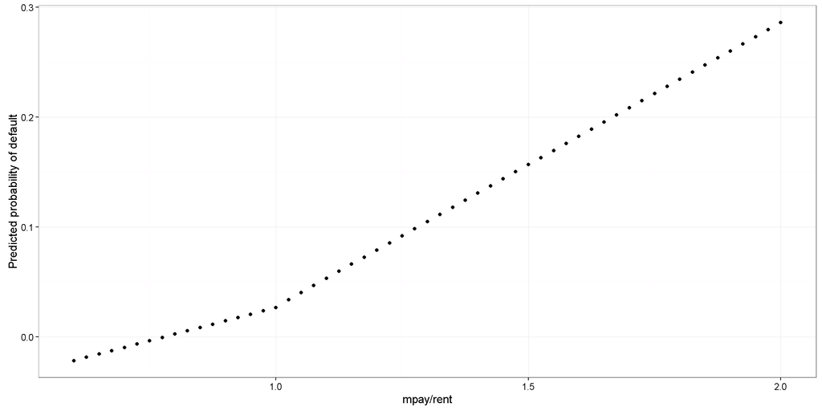

### Two Stage Least Squres - **Matched** 10% positive equity

```
##
## ====================================================================
##                                   Dependent variable:
##                    -------------------------------------------------
##                                 def               adjusted_mpay_rent
##                       OLS        instrumental            OLS
##                                    variable
##                       OLS          Two Stage         First Stage
##                       (1)       (2)       (3)            (4)
## --------------------------------------------------------------------
## adjusted_mpay_rent  0.234***  0.197***  0.093***
##                     (0.007)   (0.016)   (0.016)
## interestrate_avg                                       0.097***
##                                                        (0.001)
## age_t                                                  0.001***
##                                                       (0.00002)
## fico               -0.0004***          -0.0004***    -0.00002***
##                    (0.00002)           (0.00002)      (0.00001)
## ltv                -0.0004***          -0.0003***      0.002***
##                     (0.0001)            (0.0001)       (0.0001)
## dti                0.0004***           0.0004***       -0.00002
##                     (0.0001)            (0.0001)      (0.00004)
## log(upb)           -0.023***             0.0003        0.117***
##                     (0.005)             (0.005)        (0.003)
## current_hv_cat      0.004***  0.001**    0.0001       -0.015***
##                     (0.001)   (0.0003)  (0.001)        (0.0003)
## interest_diff        -0.564              0.004         0.552***
##                     (3.041)             (0.014)        (0.008)
## Constant            0.433***   -0.127   0.285***      -1.436***
##                     (0.146)   (0.094)   (0.108)        (0.059)
## --------------------------------------------------------------------
## zip * year            Yes       Yes       Yes            Yes
## purpose                No        No        No             No
## occupancy              No        No        No             No
## --------------------------------------------------------------------
## Observations         57,192    58,309    57,192         57,192
## Adjusted R2          0.045     0.033     0.038          0.701
## ====================================================================
## Note:                                    *p<0.1; **p<0.05; ***p<0.01
```

### Two Stage Least Squres - **Matched** 10% positive equity & mpay/rent > 1

```
##
## ===================================================================
##                                  Dependent variable:
##                    ------------------------------------------------
##                                 def              adjusted_mpay_rent
##                       OLS       instrumental            OLS
##                                   variable
##                       OLS         Two Stage         First Stage
##                       (1)       (2)       (3)           (4)
## -------------------------------------------------------------------
## adjusted_mpay_rent 0.431***  0.222***   -0.037
##                     (0.018)   (0.061)   (0.045)
## interestrate_avg                                      0.088***
##                                                       (0.002)
## age_t                                                0.0003***
##                                                      (0.00003)
## fico               -0.001***           -0.001***    -0.00003***
##                    (0.00003)           (0.00003)     (0.00001)
## ltv                -0.002***           -0.001***      0.002***
##                    (0.0002)            (0.0002)       (0.0001)
## dti                0.001***            0.001***       0.00002
##                    (0.0001)            (0.0001)       (0.0001)
## log(upb)           -0.060***           -0.023**       0.061***
##                     (0.011)             (0.011)       (0.004)
## current_hv_cat     0.009***   0.001**   0.003*       -0.007***
##                     (0.001)   (0.001)   (0.002)       (0.001)
## interest_diff       -0.172              -0.035        0.477***
##                     (0.401)             (0.029)       (0.010)
## Constant           0.578***  -0.296*** 0.841***        -0.062
##                     (0.128)   (0.089)   (0.131)       (0.047)
## -------------------------------------------------------------------
## zip * year            Yes       Yes       Yes           Yes
## purpose               No        No        No             No
## occupancy             No        No        No             No
## -------------------------------------------------------------------
## Observations        20,805    21,308    20,805         20,805
## Adjusted R2          0.116     0.084     0.079         0.526
## ===================================================================
## Note:                                   *p<0.1; **p<0.05; ***p<0.01
```

### Zipcode level regression: default % ~ median mpay_rent

```r
median_mpay_zillow <- ddply(zillow_cox,.(ne_qt,ne_cutoff,recourse,state,zip),summarise,
                     def=mean(def,na.rm = TRUE),
                     adjusted_mpay_rent = mean(adjusted_mpay_rent,na.rm = TRUE),
                     fico = mean(fico,na.rm = TRUE),
                     ltv = mean(ltv,na.rm = TRUE),
                     dti = mean(dti,na.rm = TRUE),
                     ne_year = mean(ne_year,na.rm = TRUE),
                     upb = mean(upb,na.rm = TRUE),
                     age_t = mean(age_t, na.rm = TRUE),
                     medhhincome = mean(medhhincome,na.rm = TRUE),
                     medhouseage = mean(medhouseage,na.rm = TRUE),
                     vacantpct = mean(vacantpct,na.rm = TRUE),
                     median_forc_time = mean(median_forc_time,na.rm = TRUE),
                     bachelorpct = mean(bachelorpct,na.rm = TRUE),
                     withsalarypct = mean(withsalarypct,na.rm = TRUE),
                     interest_diff = mean(interest_diff,na.rm = TRUE),
                     default_pct=mean(default_pct,na.rm = TRUE),
                     hpi_change = mean(hpi_change,na.rm=TRUE),
                     forc_pct = mean(forc_pct,na.rm = TRUE),
                     obs = length(loanid))



median_mpay_zillow['low_obs']<-ifelse(median_mpay_zillow$obs<5,1,0)

ddply(median_mpay_zillow,.(low_obs),summarise,ltv = mean(ltv,na.rm = TRUE),ltv = mean(ltv,na.rm = TRUE),interest_diff=mean(interest_diff,na.rm = TRUE))
```

```
##   low_obs      ltv interest_diff
## 1       0 83.74004    0.01133779
## 2       1 87.76204    0.02214943
```

```r
ols <- list()
se <- list()
marginal_effects <- list()

ols_formula <- as.formula("def~adjusted_mpay_rent+interest_diff+median_forc_time+factor(state)+fico+ltv+dti+log(upb)+medhhincome+medhouseage+vacantpct+bachelorpct+withsalarypct+default_pct+hpi_change+forc_pct")


ols[[1]]<-lm(ols_formula,data=median_mpay_zillow[median_mpay_zillow$ne_cutoff==-0.01,])
se[[1]] <- sqrt(diag(vcovHAC(ols[[1]])))

marginal_effects[[1]] <- summary(ols[[1]])$coefficients[2]*sd(median_mpay_zillow[median_mpay_zillow$ne_cutoff==-0.01,]$adjusted_mpay_rent)

ols[[2]]<-lm(ols_formula,data=median_mpay_zillow[median_mpay_zillow$ne_cutoff==-0.1,])
se[[2]] <- sqrt(diag(vcovHAC(ols[[2]])))

marginal_effects[[2]] <- summary(ols[[2]])$coefficients[2]*sd(median_mpay_zillow[median_mpay_zillow$ne_cutoff==-0.1,]$adjusted_mpay_rent)

stargazer(ols, omit = c("state","ne_qt","ne_cutoff"), column.labels=c('NE 0','NE -10%'), omit.labels = c("State","Time","Negative Equity"), type=output.type,no.space=TRUE,se=se,omit.stat = c("f","ser"),add.lines = list(c("Marginal Effect (per 1sd)", round(marginal_effects[[1]],3),round(marginal_effects[[2]],3))),notes = "~Robust SE")
```

```
##
## ======================================================
##                               Dependent variable:
##                           ----------------------------
##                                       def
##                                NE 0         NE -10%
##                                (1)            (2)
## ------------------------------------------------------
## adjusted_mpay_rent           0.145***       0.084*
##                              (0.041)        (0.051)
## interest_diff                 0.488        0.977***
##                              (0.359)        (0.369)
## median_forc_time              -0.001        -0.008
##                              (0.011)        (0.014)
## fico                        -0.004***      -0.004***
##                              (0.0005)       (0.001)
## ltv                         -0.025***      -0.023***
##                              (0.002)        (0.003)
## dti                          0.009***       0.004**
##                              (0.002)        (0.002)
## log(upb)                    -0.276***       -0.132*
##                              (0.064)        (0.073)
## medhhincome                  -0.00000       0.00000
##                             (0.00000)      (0.00000)
## medhouseage                   0.001          0.002
##                              (0.002)        (0.002)
## vacantpct                     -0.077        -0.336
##                              (0.397)        (0.494)
## bachelorpct                  1.625***        0.316
##                              (0.595)        (0.641)
## withsalarypct                 -0.183         0.222
##                              (1.150)        (1.303)
## default_pct                   2.882          1.947
##                              (4.856)        (5.979)
## hpi_change                    0.421          0.104
##                              (0.346)        (0.387)
## forc_pct                   -129.976***    -112.742**
##                              (45.559)      (54.419)
## Constant                     8.492***      7.001***
##                              (0.902)        (1.030)
## ------------------------------------------------------
## State                          Yes            Yes
## Time                            No            No
## Negative Equity                 No            No
## ------------------------------------------------------
## Marginal Effect (per 1sd)     0.051          0.029
## Observations                  1,212           987
## R2                            0.288          0.231
## Adjusted R2                   0.260          0.195
## ======================================================
## Note:                      *p<0.1; **p<0.05; ***p<0.01
##                                             ~Robust SE
```

### Zip code level sold pct and inventory number

Percentage Houses Sold in each 3 digit zip code and for sale inventory in each zip code (Using the median age to calculate mpay)

```r
# created by zipcode_level_reg_freddie_zillow.R
decile_data <- readRDS(paste(file_path,"decile_stats_merged.rds",sep=""))
decile_data['new_default_pct']<- decile_data$freddie_no_of_defaults*100/decile_data$freddie_no_of_loans
decile_data$ne_default_pct=decile_data$ne_default_pct*100

stargazer(
  decile_data[decile_data$age_decile==5, c("sold_pct","ne_default_pct","inventory_value","mpay_rent","mpay","rent")], type = output.type,
  summary.stat = c("mean", "sd","min", "p25", "median", "p75", "max")
)
```

```
##
## ====================================================================================
## Statistic         Mean    St. Dev.    Min   Pctl(25)   Median   Pctl(75)     Max
## ------------------------------------------------------------------------------------
## sold_pct          5.205     1.738    0.706    3.979     4.999     6.156     13.338
## ne_default_pct   41.247    38.531    0.000    9.323    23.077    83.333    100.000
## inventory_value 4,050.542 3,299.279   109     1,725     3,181     5,501     25,277
## mpay_rent         0.685     0.238    0.058    0.519     0.646     0.814     2.722
## mpay             980.030   543.512  361.164  631.799   851.082  1,153.173 9,050.390
## rent            1,552.904 1,469.077 500.000 1,095.000 1,272.500 1,611.875 33,500.000
## ------------------------------------------------------------------------------------
```

```r
ols <- list()
se <-list()
ols[[1]] <- lm(sold_pct~mpay_rent+fico+ltv+dti+medhhincome+medhouseage+vacantpct+bachelorpct+withsalarypct+age+factor(state)+factor(current_year),data=decile_data[decile_data$age_decile==5,])
  se[[1]] <-sqrt(diag(cluster.vcov(ols[[1]], cbind(decile_data[decile_data$age_decile==5,]$state,decile_data[decile_data$age_decile==5,]$current_year))))
stargazer(ols, omit = c("state","current_year"),omit.labels = c("State","Year"),type=output.type,no.space=TRUE,notes = "~SE Clusterd by state and time")
```

```
##
## ==================================================
##                          Dependent variable:
##                     ------------------------------
##                                sold_pct
## --------------------------------------------------
## mpay_rent                      1.043***
##                                (0.085)
## fico                          -0.012***
##                                (0.002)
## ltv                           -0.024***
##                                (0.005)
## dti                             0.009
##                                (0.010)
## medhhincome                   0.0001***
##                               (0.00000)
## medhouseage                    0.012***
##                                (0.003)
## vacantpct                     -1.628***
##                                (0.465)
## bachelorpct                    1.793***
##                                (0.549)
## withsalarypct                 -8.204***
##                                (1.512)
## age                            0.008**
##                                (0.003)
## Constant                      12.532***
##                                (2.042)
## --------------------------------------------------
## State                            Yes
## Year                             Yes
## --------------------------------------------------
## Observations                    4,779
## R2                              0.652
## Adjusted R2                     0.649
## Residual Std. Error       1.015 (df = 4734)
## F Statistic           201.879*** (df = 44; 4734)
## ==================================================
## Note:                  *p<0.1; **p<0.05; ***p<0.01
##                     ~SE Clusterd by state and time
```

### Prepayment Loanmonth

```r
# rm(list=ls())
# library(data.table)
# library(zoo)
# library(sqldf)
# library(stargazer)
# library(survival)
# library(reshape2)
# library(zipcode)
# library(ggplot2)
# library(multiwayvcov)
# library(sandwich)
# library(AER)
# file_path = "E:/strategic_default/"
# setwd(file_path)
# source("functions.R")
# output.type = "html"
#
#
# deldata_zillow <- readRDS(paste(file_path,"prepay_loanmonth_zillow.rds",sep=""))
# deldata_zillow['current_year'] <- as.numeric(format(deldata_zillow$reportingperiod_t,"%Y"))
#
# gc(reset = TRUE)
#
# logit <- list()
# logit[[1]] <- glm(prepaid~mpay_zillow_rent+interestrate+current_equity+I(age_t)+I(age_t^2)+I(age_t^3)+I(age_t^4)+I(age_t^5)+fico+ltv+dti+interestrate+factor(state)+factor(current_year),family='binomial',data=deldata_zillow,maxit=100)
# logit[[2]] <- glm(prepaid~mpay_zillow_rent+interestrate+current_equity+I(age_t)+I(age_t^2)+I(age_t^3)+I(age_t^4)+I(age_t^5)+fico+ltv+dti+interestrate+factor(state)+factor(current_year),family='binomial',data=deldata_zillow[deldata_zillow$current_equity>=0,],maxit=100)
#
# stargazer(logit,type=output.type,no.space=TRUE,omit = c("state","current_year"),omit.labels = c("State","Year"),column.labels=c('All','Positive Equity'))


# ===============================================
#                        Dependent variable:
#                   -----------------------------
#                              prepaid
#                        All      Positive Equity
#                        (1)            (2)
# -----------------------------------------------
# mpay_zillow_rent    0.596***       0.507***
#                      (0.015)        (0.016)
# interestrate        0.015***       0.019***
#                      (0.005)        (0.006)
# current_equity      0.662***       0.431***
#                      (0.017)        (0.024)
# I(age_t)            0.114***       0.123***
#                      (0.003)        (0.003)
# I(age_t2)           -0.003***      -0.003***
#                     (0.0001)       (0.0001)
# I(age_t3)          0.00003***     0.00003***
#                     (0.00000)      (0.00000)
# I(age_t4)          -0.00000***    -0.00000***
#                      (0.000)        (0.000)
# I(age_t5)           0.000***       0.000***
#                      (0.000)        (0.000)
# fico                0.004***       0.004***
#                     (0.0001)       (0.0001)
# ltv                 -0.002***      -0.003***
#                     (0.0002)       (0.0003)
# dti                 -0.003***      -0.003***
#                     (0.0002)       (0.0002)
# Constant            -9.362***      -8.932***
#                      (0.131)        (0.134)
# -----------------------------------------------
# State                  Yes            Yes
# Year                   Yes            Yes
# -----------------------------------------------
# Observations        8,631,740      7,538,121
# Log Likelihood    -740,960.700   -656,376.900
# Akaike Inf. Crit. 1,482,025.000  1,312,858.000
# ===============================================
# Note:               *p<0.1; **p<0.05; ***p<0.01
```